# Are ants botanists? Ant associative learning of plant chemicals mediates foraging for carbohydrates - Nelson - 2020 - Ecological Entomology - Wiley Online Library

[Ecological Entomology](https://onlinelibrary.wiley.com/journal/13652311)

[Volume 45, Issue 2](https://onlinelibrary.wiley.com/toc/13652311/2020/45/2)

Original Article

Full Access

# Are ants botanists? Ant associative learning of plant chemicals mediates foraging for carbohydrates

[Annika S. Nelson](https://onlinelibrary.wiley.com/action/doSearch?ContribAuthorStored=Nelson%2C+Annika+S)

[Guillermo D. Zapata](https://onlinelibrary.wiley.com/action/doSearch?ContribAuthorStored=Zapata%2C+Guillermo+D)

[Keegan T. Sentner](https://onlinelibrary.wiley.com/action/doSearch?ContribAuthorStored=Sentner%2C+Keegan+T)

[Kailen A. Mooney](https://onlinelibrary.wiley.com/action/doSearch?ContribAuthorStored=Mooney%2C+Kailen+A)

First published: 09 August 2019

https://doi.org/10.1111/een.12794

Associate Editor: Simon Leather

## Abstract

1. Although associative learning is widespread across animals, its ecological importance is difficult to assess because learning is rarely studied in the field, where informative cues are juxtaposed against complex backgrounds of uninformative noise.

2. Ants rely heavily on chemical cues for foraging and engage in many ecologically important interactions with plants. Nevertheless, little is known about the role of associative learning of plant chemicals in ant foraging for carbohydrates.

3. In a field setting, the present study investigated whether the distantly related ant species *Formica podzolica* (Formicinae subfamily) and *Tapinoma sessile* (Dolichoderinae subfamily) exhibited associative learning of the chemical cues from two co‐occurring plant species that are taxonomically and chemically distinct (Asteraceae: *Helianthella quinquenervis* and Apiaceae: *Ligusticum porteri*).

4. For two consecutive summers, ants were trained to forage from artificial sugar‐rich baits associated with the leaf chemicals from either *H. quinquenervis* or *L. porteri* for 24 h, after which a two‐choice test was deployed to assess whether ants would be more likely to select baits associated with the same (versus different) plant chemicals on which they had been trained.

5. The present study demonstrates associative learning of chemicals from both plant species, and these effects were consistent between ant species and years; training increased bait occupancy from 42% on the untrained scent to 66% on the trained scent. These results indicate that associative odour‐learning may be widespread across ants and serve as an important mechanism mediating ant selection of resources.

## Introduction

Associative learning, comprising the formation of predictive relationships between contingent stimuli in the environment, is widespread across animals and likely has far‐reaching ecological and evolutionary consequences (Giurfa, 2007; Ginsburg & Jablonka, 2010; Morand‐Ferron, 2017). Associative learning can result in adaptive behavioural changes and increased foraging efficiency, such as when birds develop search images for cryptic moth prey (Tinbergen, 1960; Pietrewicz & Kamil, 1979), when bees form associations between floral colour and nectar rewards (von Frisch, 1914; Gumbert, 2000) and when parasitoid wasps learn to locate prey based on olfactory cues (Ishii & Shimada, 2010). In turn, associative learning is considered to result in the evolution of new traits (e.g. anti‐predator defences in prey) (Ginsburg & Jablonka, 2010) and to structure populations and communities of associated species (Ishii & Shimada, 2010). For example, search images in birds can result in frequency‐dependent foraging, with birds increasing their consumption of abundant prey but decreasing their consumption of rare prey, thus maintaining colour polymorphisms and species coexistence in cryptic moths (Bond & Kamil, 1998).

However, because most studies of associative learning are conducted in the laboratory, we often lack information about the ecological and evolutionary relevance of associative learning under field conditions (Pritchard *et al*., 2016; Morand‐Ferron, 2017). Although laboratory tests of learning allow for greater experimental control, animals have access to different information and are under different selective pressures in the wild (Pritchard *et al*., 2016; Muth *et al*., 2018). As a result, estimates of learning performance in the laboratory may not translate to the field. Although recent studies provide field‐based evidence for associative learning in both vertebrates (Morand‐Ferron *et al*., 2015) and invertebrates (Huber & Knaden, 2018), additional field studies are needed to understand the extent to which associative learning influences species interactions in the wild.

Because ants rely heavily on chemical cues when foraging and engage in many ecologically important interactions with plants, associative learning of plant chemicals could mediate ant discovery and selection of plant‐associated resources (Nelson *et al*., 2019). Ants have widespread effects in most terrestrial ecosystems, where they engage with plants by visiting flowers, dispersing and preying on seeds, cutting leaves, protecting plant and insect–herbivore mutualists from their natural enemies, and serving as prey for carnivorous plants (Nelson *et al*., 2019). Such encounters with plants are likely the result of ants using both pheromonal (Morgan, 2009) and non‐pheromonal (hereafter ‘ambient’) chemicals in the environment to navigate and locate resources (Knaden & Graham, 2016). Compared with other insects such as honeybees, for which associative odour‐learning has been extensively studied (Giurfa & Sandoz, 2012), ants are known to have larger and more complex olfactory regions of the brain, highlighting the centrality of chemical detection to ant foraging (Gronenberg, 1996). All below‐ and above‐ground plant tissues are known to produce ambient chemicals, including both volatile and non‐volatile compounds on tissue surfaces, and ants could exhibit both innate (Edwards *et al*., 2006; Dáttilo *et al*., 2009) and learned responses to these chemicals. Interestingly, because ants live in colonies, associative learning by individual ant foragers could be socially transmitted not only through the recruitment of additional foragers with pheromone trails, but also through mouth‐to‐mouth food exchange (trophallaxis) in which otherwise naïve foragers learn to associate rewards with the chemical cues of the exchanged food (Provecho & Josens, 2009; Hayashi *et al*., 2017). Thus, although associative odour‐learning in ants has received less attention compared with in other animals (Giurfa, 2007), it may commonly mediate ant interactions with plants.

Past studies provide evidence for visual and olfactory learning by ants (Roces, 1994; Harris *et al*., 2005; Dupuy *et al*., 2006; Narendra *et al*., 2007; Bos *et al*., 2010) but, to our knowledge, no studies have tested whether associative learning of natural blends of plant chemicals by ants mediates their associations with plants in the field. Associative learning has only been studied in a few ant species (*Acromyrmex lundi*, *Camponotus* spp. and *Cataglyphis fortis*) (Roces, 1994; Helmy & Jander, 2003; Huber & Knaden, 2018), thus making it unclear whether learning is widespread across ants. Most of these studies have been conducted in the laboratory, in which ants have been shown to form positive and negative associations with pure chemical compounds (Dupuy *et al*., 2006; Josens *et al*., 2009), artificial odours (Roces, 1990, 1994) and the cuticular hydrocarbon profiles of other ants (Bos *et al*., 2010). Such experiments provide opportunity for controlled tests of ant associative learning and its underlying mechanisms (e.g. individual versus social learning), although they lack ecological complexity and realism. Field‐based studies have also shown that ants learn food odours (Helmy & Jander, 2003; Huber & Knaden, 2018) and use scents as landmarks for navigation (Wolf & Wehner, 2000; Steck *et al*., 2009; Buehlmann *et al*., 2015). However, most of these studies tested for associative learning using single chemical compounds, rather than natural blends of chemicals present in the environment (Steck *et al*., 2009; Buehlmann *et al*., 2015; Huber & Knaden, 2018). Although several studies indicate that ants may associatively learn natural blends of plant chemicals, evidence is scant and inconclusive. For example, one study provides preliminary evidence that ants associatively learn plant odours (Helmy & Jander, 2003), although foragers were assayed from only two replicate colonies, and training was performed on the colony surface where competing chemical stimuli were likely minimal. Similarly, although several field‐based studies have shown that ants recruit faster and forage more efficiently on plant‐based resources (seeds or leaves) that are more familiar, the mechanisms (e.g. ant odour‐learning) driving these patterns were not assessed (Fowler, 1982; Johnson, 1991; Howard *et al*., 1996). Thus, additional studies are needed to determine whether associative learning of plant odours by ants mediates ecologically important interactions between ants and plants.

In the present study, we assessed whether ants associatively learn plant chemicals when foraging for sugar‐rich resources in the field. Accordingly, we tested whether ants exhibited associative learning when trained to forage for baits associated with leaf chemicals from two co‐occurring taxonomically and chemically distinct plant species (Asteraceae: *Helianthella quinquenervis* and Apiaceae: *Ligusticum porteri*) that both naturally produce sugar‐rich rewards for ants (extrafloral nectar and honeydew excreted by aphids, respectively) (Inouye & Taylor, 1979; Mooney *et al*., 2016). By testing for associative learning of chemicals from both plant species by two ecologically and taxonomically distinct ant species (Dolichoderinae: *Tapinoma sessile* and Formicinae: *Formica podzolica*) across 2 years, we provide evidence that associative odour‐learning may be an important mechanism mediating ant foraging in the field.

## Materials and methods

### *Study sites and natural history*

The present study was conducted in July 2017 and 2018 near the Rocky Mountain Biological Laboratory (RMBL) in Gothic, CO (38.96°N, 106.99°W). In 2017 and 2018, we worked along seven and eight (respectively) transects in open, rocky meadows distributed within a 4‐km radius (15 total transects; coordinates provoided in the Supporting information, Table S1). In these sites *Helianthella quinquenervis* (Asteraceae; ‘aspen sunflower’) and *Ligusticum porteri* (Apiaceae; ‘osha’) are the two dominant herbaceous, comprising perennial plants that are both naturally associated with sugar‐rich rewards for ants (extrafloral nectar and honeydew excreted by aphids, respectively) (Inouye & Taylor, 1979; Mooney *et al*., 2016). Plants in the Apiaceae and Asteraceae family share many secondary compounds in common, including some aromatic essential oils and terpenoids in leaves and other plant tissues (Berenbaum, 2001). However, Apiaceae plants are known to have particularly distinctive odours and produce compounds such as furanocoumarins that are not present in the Asteraceae (Berenbaum, 2001). In the field, *H. quinquenervis* and *L. porteri* are distinguishable by scent (A. S. Nelson, personal observations).

The five taxonomic groups of ants that commonly occur in these sites are *Camponotus* spp., *Formica podzolica*, and the *Formica rufa* species group (subfamily Formicidae), *Myrmica* spp. (subfamily Myrmicinae) and *Tapinoma sessile* (subfamily Dolichoderinae). Ants in these three subfamilies have independently evolved to rely on sugar‐rich liquid rewards (e.g. extrafloral nectar and honeydew produced by hemipterans) as main components of their diets (Hölldobler & Wilson, 1990). Of the taxa in this community, *F. podzolica* and *T. sessile* are the most abundant (Mooney *et al*., 2016) and were most frequently observed in the present study. *Formica podzolica* and *T. sessile* have contrasting colony structures; *F. podzolica* forms large colonies (approximately 5000–40 000 workers) with multiple queens that often occupy multiple nests (Deslippe & Savolainen, 1994; DeHeer & Herbers, 2004), whereas *T. sessile* forms small colonies (approximately 70 workers) with single queens that occupy single nests (Buczkowski, 2010). Although *F. podzolica* is a non‐aggressive, competitively subordinate species (Savolainen, 1990; Mooney, 2006), *T. sessile* is more behaviourally and numerically dominant (A. S. Nelson & K. A. Mooney, unpublished data).

### *Experimental design*

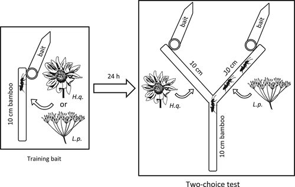

**Figure 1**

First, ants were trained to forage for resources from baits (‘training baits’) associated with chemicals from either *Helianthella quinquenervis* (‘H.q.’) or *Ligusticum porteri* (‘L.p.’) leaves, which were rubbed on bamboo sticks to which the baits were attached. After 24 h, we deployed a two‐choice test within 50 cm of the training baits. We placed one bait at the end of each arm of the two‐choice test, and we rubbed one arm with *H. quinquenervis* leaves and the other with *L. porteri* leaves. Then every 10–20 min for the subsequent 2–3 h, we recorded whether ants were present (in both 2017 and 2018) and their identities (in 2018 only) on all arms and baits of the two‐choice test to test whether ants were more likely to select baits associated with the leaf chemicals on which they had been trained.

To test for associative odour‐learning, we used baits that were intended to imitate the composition of mutualist‐produced resources associated with plants (i.e. extrafloral nectar or honeydew) and consisted of 10 ml of a 20% solution by mass of forest honey (honey produced by bees that foraged on hemipteran honeydew; Langnese Forest Honey, Bargteheide, Germany) in 15‐ml plastic centrifuge tubes fitted with cotton wicks. We attached training baits to the top of 10‐cm sanded and lacquered bamboo sticks, which were used as artificial plant stems. We rubbed the sticks once with fresh leaves from either *H. quinquenervis* or *L. porteri* (alternating between species along the transect) when baits were first deployed. Leaves were locally collected from plants that visually appeared to be undamaged by herbivores. Because leaves were crushed in the process of rubbing them along bamboo sticks, they may have released additional chemical compounds compared with undamaged leaves. However, because plants often release additional chemical compounds in response to natural herbivore damage (Dicke & Baldwin, 2010), these chemical compounds would likely still be naturally available to be detected by ants. Moreover, we used bamboo sticks (that were presumably odourless) rather than natural plant stems so that other non‐olfactory cues (e.g. textural or visual) from *H. quinquenervis* and *L. porteri* would not affect ant behaviour.

After training baits were deployed for 24 h, we deployed a two‐choice test within 50 cm of each training bait to assess whether ants would be more likely to select baits associated with leaf chemicals from the same (versus different) plant species on which they had previously been trained (Fig. 1). The base and arms of the two‐choice test consisted of bamboo sticks (length 10 cm), with the arms positioned at a 90° angle. We placed one honey bait at the end of each arm of the two‐choice test, randomly selecting one arm to rub with *H. quinquenervis* leaves and the other to rub with *L. porteri* leaves. The base of the two‐choice test was unscented. We removed any vegetation that was touching the two‐choice test so that ants could only access the baits by ascending the base and subsequently selecting one of the arms. Every 10–20 min for the subsequent 2–3 h, we recorded whether ants were present (in both years) and their identities (in 2018 only), both in the baits and ascending the arms of the two‐choice test. We considered baits to have been occupied by ants if ants were ever observed feeding in the baits. Although any ant could ascend the two‐choice test (whether or not it had previously been trained), it is likely that ants in most locations had received prior training (with 94% of the training baits having been discovered by ants).

### *Statistical analysis*

We used two separate models to test for associative learning (i) by two ant species (*F. podzolica* and *T. sessile*) that were most commonly observed in 2018 and (ii) by all ant taxa combined in both 2017 and 2018 (after excluding locations where ants were never observed feeding from any baits). For both tests, we used generalised linear mixed models (GLMM) with binomial distributions to assess whether bait selection depended on the main effects of bait scent and whether ants had been trained on the same (versus different) scent (hereafter ‘same‐odour training’), as well as the bait scent × same‐odour training interaction. A significant positive main effect of same‐odour training would demonstrate associative learning. A significant main effect of bait scent would indicate that there were different responses to the two plant species, regardless of experimental training. Finally, a significant bait scent × same‐odour training interaction would indicate that associative learning of one plant species was stronger than of the other. The model testing for learning in the two ant species in 2018 also included the main effect of ant species, as well as all two‐ and three‐way interactions, to test whether learning was ant species‐dependent. The model testing for learning in all ant taxa combined across both years included the main effect of year, as well as all two‐ and three‐way interactions, to test whether learning varied between years. Both models included site as a random effect. Because of low replication within transects (with only one or two baits being discovered by ants in some transects), it was not possible to include transect (*n* = 15) as a random effect (models were over‐fitted; not enough degrees of freedom). Moreover, the biotic and abiotic factors that might influence our results (including aspect, plant community composition and soil type) varied at a scale larger than the individual transect; some transects neighboured others and were essentially in the same biotic and abiotic setting. Thus, we grouped the transects into seven distinct sites, and we included site as a random effect in both models.

All analyses were conducted in r, version 3.3.2 (R Core Team, 2016). We constructed GLMMs using the ‘glmer()’ function in the ‘lme4’ package (Bates *et al*., 2015). To test for the significance of effects, we conducted Wald chi‐squared tests with type III sums of squares using the ‘Anova()’ function in the ‘car’ package (Fox & Weisberg, 2010).

## Results

In the model testing for learning by *F. podzolica* and *T. sessile* in 2018, there was a significant positive effect of same‐odour training (GLMM: χ<sup>2</sup> = 5.30, *P* = 0.021), where ants selected a greater proportion of baits scented with the plant chemicals on which they had been trained; for both ant species combined, same‐odour training increased bait occupancy from 45% to 66% (Fig. 2). The main effects of bait scent and ant species were not statistically significant (*P* > 0.09 in both cases) and neither were any of the two‐ or three‐way interactions (*P* > 0.60 in all cases). Accordingly, we found evidence for associative learning that did not detectably differ with ant species or plant scent.

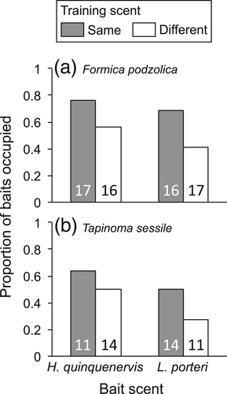

**Figure 2**

The effects of training (colour) and bait scent (*x*‐axis) on the proportion of baits occupied by (a) *Formica podzolica* and (b) *Tapinoma sessile*, the two most common ant species observed in baits in 2018. Numbers inside the bars indicate sample sizes. Overall, ants occupied a significantly greater proportion of the baits associated with the same (versus different) chemical cues on which they had been trained (generalised linear mixed model: χ<sup>2</sup> = 5.31, *P* = 0.021).

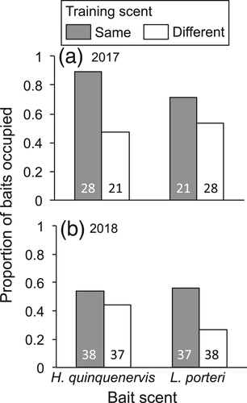

**Figure 3**

The effects of training (colour) and bait scent (*x*‐axis) on the proportion of baits occupied by all ant taxa combined in (a) 2017 and (b) 2018. Numbers inside the bars indicate sample sizes. Overall, ants occupied a significantly greater proportion of the baits associated with the same (versus different) chemical cues on which they had been trained (generalised linear mixed model: χ<sup>2</sup> = 16.19, *P* < 0.001). There was also a significant main effect of year (generalised linear mixed model: χ<sup>2</sup> = 11.49, *P* < 0.001), with ants occupying more baits in 2017 than 2018. The bait scent × training × year interaction was marginally significant (generalised linear mixed model: χ<sup>2</sup> = 3.72, *P* = 0.054), although no other main or interactive effects were statistically significant.

## Discussion

We have demonstrated that associative learning of natural blends of plant chemicals mediates the selection of carbohydrates by two ant species across 2 years in the field. In 2018, two taxonomically and ecologically distinct ant species were both more likely to select artificial sugar‐rich rewards associated with the same (versus different) plant leaf chemicals on which they had previously been trained, and such effects did not detectably differ with ant or plant species; overall, same‐odour training increased bait occupancy by these two ant species from 45% to 66%. Moreover, we found consistent evidence for associative learning with all ant taxa in the community combined across 2 years (2017 and 2018); overall, same‐odour training increased bait occupancy by the ant community from 42% to 66%. Thus, we provide evidence for associative learning of plant odours as a previously uninvestigated but likely widespread mechanism mediating ant associations with plants in a chemically complex field setting.

Despite *F. podzolica* and *T. sessile* being taxonomically and ecologically distinct, we found no evidence for differences in learning between these two species (2018 data only). These ants occupy separate subfamilies that independently evolved to rely on plant‐based sugar‐rich rewards (Hölldobler & Wilson, 1990). Compared with *F. podzolica*, *T. sessile* ants have smaller brains (cross‐sectional widths of approximately 1 and 0.35 mm, respectively) (Muscedere *et al*., 2014; Sulger *et al*., 2014) and live in smaller colonies (Deslippe & Savolainen, 1994; Buczkowski, 2010), although they also often recruit more workers to baits (A. S. Nelson & K. A. Mooney, unpublished data). Such differences in brain and colony size, as well as recruitment to resources, could have potentially altered the capacity for both individual and social learning in these ants. For example, ants from larger colonies are predicted to rely more on chemical communication (Beckers *et al*., 1989) and social learning could also thus be more important. However, to our knowledge, no studies have compared the neurophysiological bases of learning or the importance of social learning in these two species. Nonetheless, we found evidence for associative learning of natural blends of plant chemicals by both ant species (2018 only), as well as by all ant taxa present in the community combined (2017 and 2018). Thus, our results contribute to a growing number of studies of associative odour‐learning in ants (Roces, 1990, 1994; Helmy & Jander, 2003; Dupuy *et al*., 2006; Bos *et al*., 2010; Huber & Knaden, 2018), which together show that associative learning of plant chemicals may be widespread across ant species.

Additional research is needed to determine whether and which plant traits mediate the strength of ant associative learning. For example, honeybees have been shown to be able to better discriminate between odours that are more dissimilar (Paldi *et al*., 2003) and it is possible that ants also exhibit stronger associative odour‐learning of plants with more dissimilar blends of chemical compounds. In co‐evolved ant–myrmecophytic plant associations, ant queens have been shown to use plant chemical compounds to distinguish between high and low quality host plants, both within and among species, as well as to select optimal hosts based on the amount of food rewards, nesting space, and previous damage from herbivores and pathogens (Torres & Sanchez, 2017; Razo‐Belman *et al*., 2018). However, it is unclear whether such responses to plant chemicals are innate or learned. In addition, the quality (i.e. composition of sugars and amino acids) and volume of sugar rewards can determine the strength of ant attraction (Blüthgen *et al*., 2004; Blüthgen & Fiedler, 2004) and could mediate the strength of associative learning, as has similarly been shown for honeybees (Wright *et al*., 2009). Thus, future studies should test for associative learning by ants of multiple plant‐associated rewards (e.g. extrafloral nectar and honeydew) of different qualities. Because ants also use visual landmarks and tactile cues when navigating (Seidl & Wehner, 2006; Steck *et al*., 2011), future studies should test whether associative learning of multiple cues in combination mediates ant foraging for plant‐associated resources (Fernandes *et al*., 2018).

In summary, we have shown that ants associatively learn chemicals from distinct plant species, and such learning may be widespread across ant taxa in the wild. In addition to associating with mutualist plants and insect herbivores, ants associate with plants in the contexts of floral visitation, seed dispersal and predation, leaf cutting, and plant predation of ants by carnivorous plants (Nelson *et al*., 2019). Thus, ant associative learning of plant chemicals may occur in many contexts (Roces, 1990; Roces, 1994) and mediate ant population‐ and community‐level effects on plants and the multi‐trophic communities in which they are embedded (Styrsky & Eubanks, 2007). As a result, ant associative learning likely has far‐reaching yet unrecognised effects on plant and insect evolutionary dynamics and community structure.

## Acknowledgements

We thank Jennifer Reithel for facilitating this research; Parker Hawk, Jackson Snow and Valerie Watson for their assistance in the field; and Dhruba Banerjee and two anonymous reviewers for providing constructive comments on the manuscript. This work was supported by the Rocky Mountain Biological Laboratory (Graduate Student Fellowship to ASN, Snyder Endowment Fellowship to ASN, Geospatial Modeling Platform); the National Science Foundation (grant numbers DBI‐1755522 to GZ, DGE‐1321846 to ASN, DEB‐0919178 to KAM, DEB‐1457029 to KAM, DBI‐040910 to Billick); the Colorado Mountain Club Foundation (Graduate Student Fellowship to ASN); and the Achievement Rewards for College Scientists Foundation (ARCS Scholar Award to ASN). The authors declare that they have no conflict of interest.

All authors designed the project. ASN, GDZ, and KTS collected the data. ASN analysed the data and wrote the paper. ASN and KAM contributed substantially to paper revisions.